# Statistics Evaluation

Thilo

# Introduction

Statistics of correlation between up/down moves and astrological features have been calculated with the goal of finding connections between e.g. a certain aspect and buy/sell days. We investigate whether the calculated frequencies, do have statistical significance. To this end, a test is performed that compares the performance of the statistics against randomness.

It has been noted, that there are some features, that show a high frequency of correlation (e.g. greater than 70%) over a period of time. The arising question is, whether this is just a product of chance or does the model have indeed predictive power. Even though such a high correlation seems very unlikely, there is a chance, that due to the large number of considered aspects/features, there are some outliers, that just by chance, show a high correlation over the considered time span.

To this end, we compare each aspect to the corresponding random behaviour and determine the p-value. The p-value is the probability, for each frequency to occur under the null hypothesis. The p-value is calculated using a two sided binomial test, since the actual probability could be higher or lower than the observed frequency.

To check, if the overall result could be random, the p-values are combined using Fisher’s-Method (https://en.wikipedia.org/wiki/Fisher%27s_method).

## Assumptions

Null hypothesis: We assume that the frequency buy/sell-days is equal to that of the underlying asset for all features.

According to the Null-hypothesis the models are described by a binomial distribution, with probability equal to the market frequency of buy days. We will make use of Fisher’s method for combining p-values.

We assume that the observations are independent. This is actually not true, because there can be aspects that often occur at the same time, e.g. while Neptune and Pluto are in a sextile aspect, a sextile aspect to Pluto is an aspect to Neptune simultaneously. Since this will only affect certain aspects, we will ignore this. If there is a significant result, the dependencies must be analysed further.

The test checks, if the result is plausible under the assumption of the null hypothesis. The alternative hypothesis is that the null hypothesis is not true, i.e. the frequency is not equal to that of the underlying asset for some features.

## Example AAPL

Determine the real market frequency of the symbol.

```r
path_market <- '../data/tmp/'


getActualFrequency <- function(symbol) {

  filename_market <- paste0(path_market, symbol, '--augmented.csv')
  market_data <- read_delim(filename_market, delim=',')
  n_days <- dim(market_data)[1]
  #frequency <- sum(market_data$CEff == 'Buy') / n_days
  frequency <- sum(market_data$OEff == 'Buy') / n_days
  return(frequency)
}

symbol = 'AAPL'
actualFrequency <- getActualFrequency(symbol)
cat(paste0('Observed frequency of buy days for ', symbol, ' is ', label_percent(accuracy=0.01)(actualFrequency)))
```

Observed frequency of buy days for AAPL is 53.24%

```r
loadAndAugmentStats <- function(symbol, file, actualFrequency) {
  filename_stats <- paste0(getwd(), '/', symbol, '/', symbol, file)
  stats <- read_delim(filename_stats, delim=',')
  p = actualFrequency # Note, if you use p=0.5, the result will be significant for some symbol. You have to use the market frequency.
  binom_partial = function(x,n) {
    pbinom(x,n, prob=p)
  }
  norm_partial = function(x,n) {
    pnorm((x+0.5-n*p)/sqrt(n*p*(1-p))) # with continuity adjustment
  }
  binom_test_pvalue = function(x,n) {
    p <- actualFrequency
    test <- binom.test(x, n, p, alternative='two.sided')
    test$p.value
  }
  stats <- stats %>% mutate(pvalue_binom = map2_dbl(Buy, DaysN, binom_test_pvalue )
                            #pvalue_norm = 1 - map2_dbl(Buy - 1, DaysN, norm_partial), # substract one buy day, because we want to know the prob    for at least this number or more
                )

}
file <- '-planets_aspects-buy_sell_count_freq_stats.csv'
stats <- loadAndAugmentStats(symbol, file, actualFrequency)
```

We can combine the p-values according to Fisher’s method.

```r
confidence_level <- 0.99
pvalues <- stats$pvalue_binom

test <- sumlog(pvalues)
cat(paste0('The p-value is using Fisher"s p-value combination method is ', test$p, '.\n\n'))
```

The p-value is using Fisher"s p-value combination method is 0.999971879169982.

```r
if(test$p < 1-confidence_level) {
  cat('We have to reject the hypothesis that the results are random.\n\n')
} else {
  cat('We cannot reject the hypothesis that the results are random.\n\n')
}
```

We cannot reject the hypothesis that the results are random.

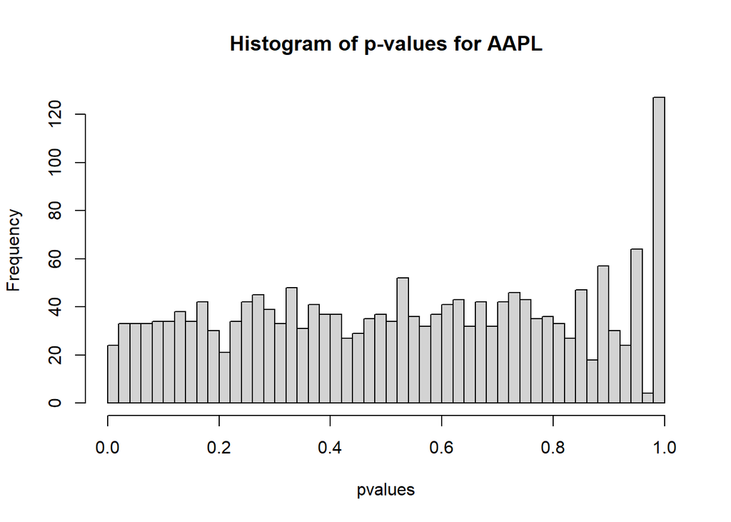

```r
hist(pvalues, breaks=50, main=paste0('Histogram of p-values for ', symbol))
```

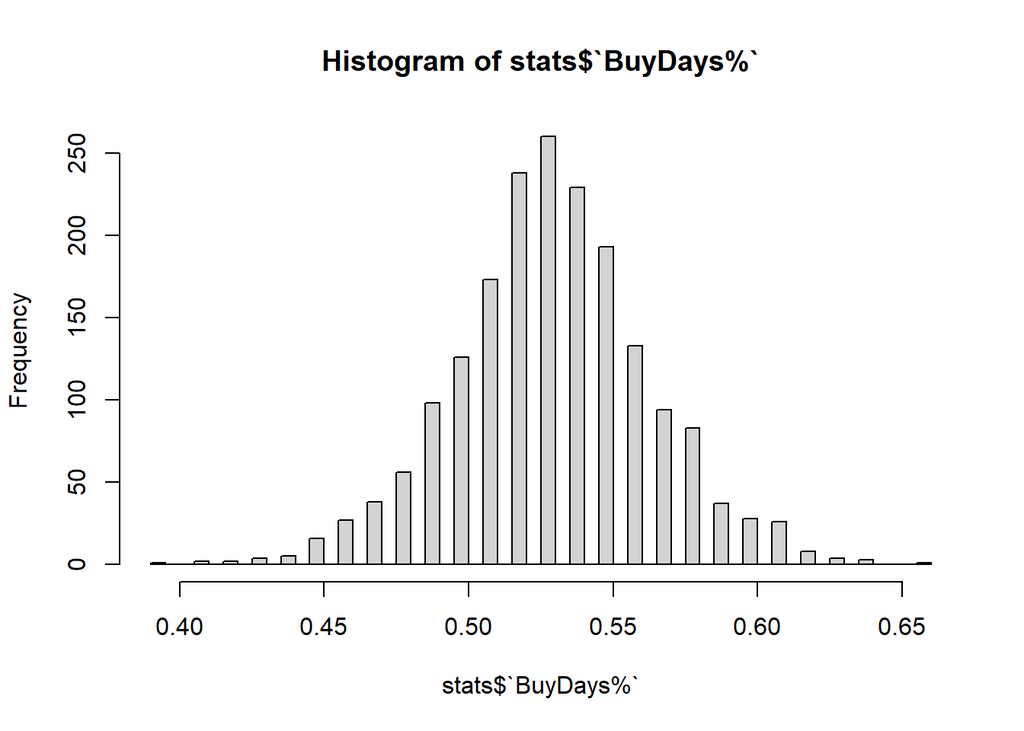

```r
hist(stats$`BuyDays%`, breaks=50)
```

# Analysis for all symbols

## Preparation

The same test is run in the following for all symbols and features.

**Important**: We check each symbol/feature type combination individually. Again, due to the multitude of checks, there can be results that appear not random. There will be final check at the end, that checks for randomness over all results.

```r
symbols=c("ADA-USD",
          "BAT-USD",
          "BNB-USD",
          "BTC-USD",
          "DASH-USD",
          "EOS-USD",
          "LINK-USD",
          "LTC-USD",
          "ZEC-USD",
          "ZRX-USD",
          "^DJI",
          "^FTSE",
          "^IBEX",
          "^IXIC",
          "^N225",
          "^NSEBANK",
          "^NSEI",
          "AAPL",
          "AMZN",
          "AXP",
          "CAT",
          "KO",
          "MSFT",
          "AUDUSD=X",
          "EURUSD=X",
          "GBPUSD=X",
          "USDCAD=X",
          "USDJPY=X")

files <-c( '-planets_aspects-buy_sell_count_freq_stats.csv',
            '-planet_zodsign-buy_sell_count_freq_stats.csv',
            '-planet_triplicity-buy_sell_count_freq_stats.csv',
            '-planet_speed-buy_sell_count_freq_stats.csv',
            '-planet_polarity-buy_sell_count_freq_stats.csv')

all_pvalues = c()
all_buyDaysPercent = c()
for (symbol in symbols){
  cat(paste0('### Testing symbol **', symbol,'**'))
  cat('\n\n')
  actualFrequency <- getActualFrequency(symbol)
  cat(paste0('Observed actual frequency of buy days for ', symbol, ' is ', label_percent(accuracy=0.01)(actualFrequency)))
  cat('\n\n')
  first = T
  for (file in files) {
    filename_stats <- paste0(getwd(), '/', symbol, '/', symbol, file)
    if(first) {
      stats <- read_delim(filename_stats, delim=',')
      first <- F
    } else {
      stats <- read_delim(filename_stats, delim=',') %>% bind_rows(stats)
    }
  }

  binom_test_pvalue = function(x,n) {
    p <- actualFrequency
    test <- binom.test(x, n, p, alternative='two.sided')
    test$p.value
  }

  stats <- stats %>%
    replace_na(list(PlanetPolarity='', PlanetSpeedPhase='', PlanetTriplicity='', PlanetZodSign='', PlanetsAspect='')) %>%
    mutate(feature = paste0(PlanetPolarity, PlanetSpeedPhase, PlanetTriplicity, PlanetZodSign, PlanetsAspect)) %>%
    mutate(pvalue_binom = map2_dbl(Buy, DaysN, binom_test_pvalue))



  pvalues <- stats$pvalue_binom
  test <- sumlog(pvalues)
  cat(paste0('The p-value combined p-value for ', symbol, ' is: ', test$p, '.\n\n'))
  if(test$p < 1-confidence_level) {
    cat('-> **NOT random**\n\n')
  } else {
    cat('-> *random*\n\n')
  }

  all_pvalues = c(all_pvalues, pvalues)
  all_buyDaysPercent = c(all_buyDaysPercent, stats$`BuyDays%`)

  cat('\n\n')
  cat('\n\n')
}
```

### Testing symbol **ADA-USD**

Observed actual frequency of buy days for ADA-USD is 50.69%

The p-value combined p-value for ADA-USD is: 0.999999999999999.

-> *random*

### Testing symbol **BAT-USD**

Observed actual frequency of buy days for BAT-USD is 49.96%

The p-value combined p-value for BAT-USD is: 1.

-> *random*

### Testing symbol **BNB-USD**

Observed actual frequency of buy days for BNB-USD is 52.28%

The p-value combined p-value for BNB-USD is: 1.

-> *random*

### Testing symbol **BTC-USD**

Observed actual frequency of buy days for BTC-USD is 54.82%

The p-value combined p-value for BTC-USD is: 0.998702322188717.

-> *random*

### Testing symbol **DASH-USD**

Observed actual frequency of buy days for DASH-USD is 48.65%

The p-value combined p-value for DASH-USD is: 0.999999492689111.

-> *random*

### Testing symbol **EOS-USD**

Observed actual frequency of buy days for EOS-USD is 49.35%

The p-value combined p-value for EOS-USD is: 1.

-> *random*

### Testing symbol **LINK-USD**

Observed actual frequency of buy days for LINK-USD is 49.84%

The p-value combined p-value for LINK-USD is: 1.

-> *random*

### Testing symbol **LTC-USD**

Observed actual frequency of buy days for LTC-USD is 49.51%

The p-value combined p-value for LTC-USD is: 1.

-> *random*

### Testing symbol **ZEC-USD**

Observed actual frequency of buy days for ZEC-USD is 47.38%

The p-value combined p-value for ZEC-USD is: 0.999866447164111.

-> *random*

### Testing symbol **ZRX-USD**

Observed actual frequency of buy days for ZRX-USD is 47.84%

The p-value combined p-value for ZRX-USD is: 1.

-> *random*

### Testing symbol **^DJI**

Observed actual frequency of buy days for ^DJI is 53.51%

The p-value combined p-value for ^DJI is: 0.999999940646957.

-> *random*

### Testing symbol **^FTSE**

Observed actual frequency of buy days for ^FTSE is 52.99%

The p-value combined p-value for ^FTSE is: 0.999998948858409.

-> *random*

### Testing symbol **^IBEX**

Observed actual frequency of buy days for ^IBEX is 52.92%

The p-value combined p-value for ^IBEX is: 0.998883464298308.

-> *random*

### Testing symbol **^IXIC**

Observed actual frequency of buy days for ^IXIC is 56.20%

The p-value combined p-value for ^IXIC is: 3.02725928686731e-12.

-> **NOT random**

### Testing symbol **^N225**

Observed actual frequency of buy days for ^N225 is 53.02%

The p-value combined p-value for ^N225 is: 0.00373744993850174.

-> **NOT random**

### Testing symbol **^NSEBANK**

Observed actual frequency of buy days for ^NSEBANK is 52.47%

The p-value combined p-value for ^NSEBANK is: 0.979388835966347.

-> *random*

### Testing symbol **^NSEI**

Observed actual frequency of buy days for ^NSEI is 52.93%

The p-value combined p-value for ^NSEI is: 0.982631765979632.

-> *random*

### Testing symbol **AAPL**

Observed actual frequency of buy days for AAPL is 53.24%

The p-value combined p-value for AAPL is: 0.999999409136296.

-> *random*

### Testing symbol **AMZN**

Observed actual frequency of buy days for AMZN is 51.51%

The p-value combined p-value for AMZN is: 0.99999984800293.

-> *random*

### Testing symbol **AXP**

Observed actual frequency of buy days for AXP is 52.96%

The p-value combined p-value for AXP is: 0.999999996517474.

-> *random*

### Testing symbol **CAT**

Observed actual frequency of buy days for CAT is 53.00%

The p-value combined p-value for CAT is: 0.868740305112068.

-> *random*

### Testing symbol **KO**

Observed actual frequency of buy days for KO is 53.77%

The p-value combined p-value for KO is: 0.99850597369105.

-> *random*

### Testing symbol **MSFT**

Observed actual frequency of buy days for MSFT is 52.95%

The p-value combined p-value for MSFT is: 0.708563236511932.

-> *random*

### Testing symbol **AUDUSD=X**

Observed actual frequency of buy days for AUDUSD=X is 51.94%

The p-value combined p-value for AUDUSD=X is: 0.999999999801627.

-> *random*

### Testing symbol **EURUSD=X**

Observed actual frequency of buy days for EURUSD=X is 50.72%

The p-value combined p-value for EURUSD=X is: 0.999999999994895.

-> *random*

### Testing symbol **GBPUSD=X**

Observed actual frequency of buy days for GBPUSD=X is 50.11%

The p-value combined p-value for GBPUSD=X is: 0.999999999881566.

-> *random*

### Testing symbol **USDCAD=X**

Observed actual frequency of buy days for USDCAD=X is 49.71%

The p-value combined p-value for USDCAD=X is: 0.999999492084855.

-> *random*

### Testing symbol **USDJPY=X**

Observed actual frequency of buy days for USDJPY=X is 51.08%

The p-value combined p-value for USDJPY=X is: 1.

-> *random*

## Combined Test

We combine the collected statistics for all symbols and features. This tests, if the overall distribution could be random.

```r
# combined test

combined_test <- sumlog(all_pvalues)

cat(paste0('*The p-value combined p-value for the combined test is: ', test$p, '.*\n'))
```

*The p-value combined p-value for the combined test is: 1.*

```r
    if(test$p < 1-confidence_level) {
      cat('**We have to reject the hypothesis that the results are random!**\n')
    } else {
      cat('**We cannot reject the hypothesis that the results are random.**\n')
    }
```

**We cannot reject the hypothesis that the results are random.**

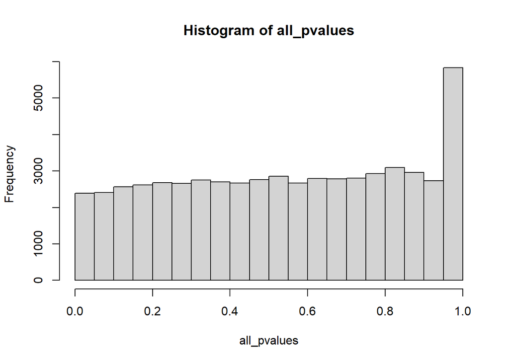

```r
hist(all_pvalues)
```

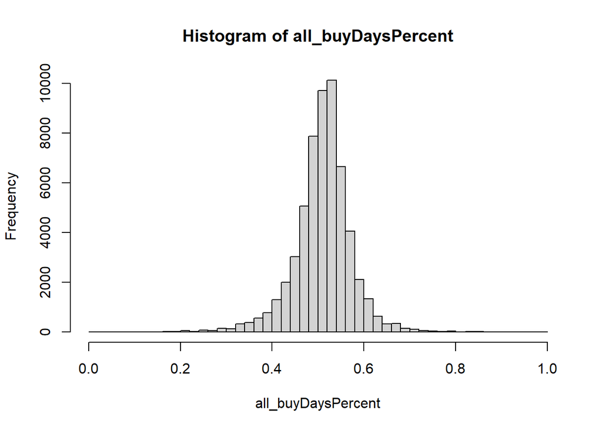

```r
hist(all_buyDaysPercent, breaks=50)
```